# Jiayi Yang STAT 6210 - Final Project

Load data

```r
rm(list=ls())
setwd("~/Data Analysis/Project")
options(max.print=1000000)
anime = read.csv(file = "anime.csv", header = TRUE)
head(anime)
```

|  | anime_id | name | genre | type | episodes | rating | members |
| --- | --- | --- | --- | --- | --- | --- | --- |
| 1 | 32281 | Kimi no Na wa. | Drama, Romance, School, Supernatural | Movie | 1 | 9.37 | 200630 |
| 2 | 5114 | Fullmetal Alchemist: Brotherhood | Action, Adventure, Drama, Fantasy, Magic, Military, Shounen | TV | 64 | 9.26 | 793665 |
| 3 | 28977 | GintamaÂ° | Action, Comedy, Historical, Parody, Samurai, Sci-Fi, Shounen | TV | 51 | 9.25 | 114262 |
| 4 | 9253 | Steins;Gate | Sci-Fi, Thriller | TV | 24 | 9.17 | 673572 |
| 5 | 9969 | Gintama&#039; | Action, Comedy, Historical, Parody, Samurai, Sci-Fi, Shounen | TV | 51 | 9.16 | 151266 |
| 6 | 32935 | Haikyuu!!: Karasuno Koukou VS Shiratorizawa Gakuen Koukou | Comedy, Drama, School, Shounen, Sports | TV | 10 | 9.15 | 93351 |

Have a look at data

```r
dim(anime)
```

```
[1] 12294     7
```

```r
str(anime)
```

```
'data.frame':   12294 obs. of  7 variables:
 $ anime_id: int  32281 5114 28977 9253 9969 32935 11061 820 15335 15417 ...
 $ name    : Factor w/ 12292 levels "&quot;0&quot;",..: 5439 2866 3361 10289 3352 3640 4321 3294 3349 3353 ...
 $ genre   : Factor w/ 3265 levels "","Action","Action, Adventure",..: 2688 163 536 3242 536 1820 365 2625 536 536 ...
 $ type    : Factor w/ 7 levels "","Movie","Music",..: 2 7 7 7 7 7 7 5 2 7 ...
 $ episodes: Factor w/ 187 levels "1","10","100",..: 1 148 133 85 133 2 42 13 1 27 ...
 $ rating  : num  9.37 9.26 9.25 9.17 9.16 9.15 9.13 9.11 9.1 9.11 ...
 $ members : int  200630 793665 114262 673572 151266 93351 425855 80679 72534 81109 ...
```

```r
summary(anime)
```

```
    anime_id
 Min.   :    1
 1st Qu.: 3484
 Median :10260
 Mean   :14058
 3rd Qu.:24795
 Max.   :34527

                                                               name
 Saru Kani Gassen                                                :    2
 Shi Wan Ge Leng Xiaohua                                         :    2
 &quot;0&quot;                                                   :    1
 &quot;Aesop&quot; no Ohanashi yori: Ushi to Kaeru, Yokubatta Inu:    1
 &quot;Bungaku Shoujo&quot; Kyou no Oyatsu: Hatsukoi             :    1
 &quot;Bungaku Shoujo&quot; Memoire                              :    1
 (Other)                                                         :12286
                   genre            type         episodes        rating
 Hentai               :  823          :  25   1      :5677   Min.   : 1.670
 Comedy               :  523   Movie  :2348   2      :1076   1st Qu.: 5.880
 Music                :  301   Music  : 488   12     : 816   Median : 6.570
 Kids                 :  199   ONA    : 659   13     : 572   Mean   : 6.474
 Comedy, Slice of Life:  179   OVA    :3311   26     : 514   3rd Qu.: 7.180
 Dementia             :  137   Special:1676   3      : 505   Max.   :10.000
 (Other)              :10132   TV     :3787   (Other):3134   NA's   :230
    members
 Min.   :      5
 1st Qu.:    225
 Median :   1550
 Mean   :  18071
 3rd Qu.:   9437
 Max.   :1013917
```

Load packages will be used

```r
library(dplyr)
library(magrittr)
library(ggplot2)
library(reshape)
library(kernlab)
```

Data cleaning split genre into dummy variables

```r
#install.packages('splitstackshape')
library(splitstackshape)
anime_split = cSplit_e(anime, "genre", ",", type = "character", fill = 0)
```

Look at the splited data

```r
str(anime_split)
```

```
'data.frame':   12294 obs. of  50 variables:
 $ anime_id           : int  32281 5114 28977 9253 9969 32935 11061 820 15335 15417 ...
 $ name               : Factor w/ 12292 levels "&quot;0&quot;",..: 5439 2866 3361 10289 3352 3640 4321 3294 3349 3353 ...
 $ genre              : Factor w/ 3265 levels "","Action","Action, Adventure",..: 2688 163 536 3242 536 1820 365 2625 536 536 ...
 $ type               : Factor w/ 7 levels "","Movie","Music",..: 2 7 7 7 7 7 7 5 2 7 ...
 $ episodes           : Factor w/ 187 levels "1","10","100",..: 1 148 133 85 133 2 42 13 1 27 ...
 $ rating             : num  9.37 9.26 9.25 9.17 9.16 9.15 9.13 9.11 9.1 9.11 ...
 $ members            : int  200630 793665 114262 673572 151266 93351 425855 80679 72534 81109 ...
 $ genre_Action       : num  0 1 1 0 1 0 1 0 1 1 ...
 $ genre_Adventure    : num  0 1 0 0 0 0 1 0 0 0 ...
 $ genre_Cars         : num  0 0 0 0 0 0 0 0 0 0 ...
 $ genre_Comedy       : num  0 0 1 0 1 1 0 0 1 1 ...
 $ genre_Dementia     : num  0 0 0 0 0 0 0 0 0 0 ...
 $ genre_Demons       : num  0 0 0 0 0 0 0 0 0 0 ...
 $ genre_Drama        : num  1 1 0 0 0 1 0 1 0 0 ...
```

[output cut: 36 more lines]

```r
colSums(is.na(anime_split))
```

```
           anime_id                name               genre                type
                  0                   0                   0                   0
           episodes              rating             members        genre_Action
                  0                 230                   0                   0
    genre_Adventure          genre_Cars        genre_Comedy      genre_Dementia
                  0                   0                   0                   0
       genre_Demons         genre_Drama         genre_Ecchi       genre_Fantasy
                  0                   0                   0                   0
         genre_Game         genre_Harem        genre_Hentai    genre_Historical
                  0                   0                   0                   0
       genre_Horror         genre_Josei          genre_Kids         genre_Magic
                  0                   0                   0                   0
 genre_Martial Arts         genre_Mecha      genre_Military         genre_Music
                  0                   0                   0                   0
      genre_Mystery        genre_Parody        genre_Police genre_Psychological
                  0                   0                   0                   0
      genre_Romance       genre_Samurai        genre_School        genre_Sci-Fi
                  0                   0                   0                   0
       genre_Seinen        genre_Shoujo     genre_Shoujo Ai       genre_Shounen
                  0                   0                   0                   0
   genre_Shounen Ai genre_Slice of Life         genre_Space        genre_Sports
                  0                   0                   0                   0
  genre_Super Power  genre_Supernatural      genre_Thriller       genre_Vampire
                  0                   0                   0                   0
         genre_Yaoi          genre_Yuri
                  0                   0
```

anime_split has 12,294 rows and 50 variables. I will not include the original genre and id. Drop name, genre and id to create new dataframe, and move rating to be the last column

```r
drops <- c('name','anime_id','genre','rating')
anime_new = anime_split[ , !(names(anime_split) %in% drops)]
anime_new = cbind(anime_new,rating = anime_split$rating)
anime_new = tbl_df(anime_new)
str(anime_new)
```

```
Classes tbl_df, tbl and 'data.frame':   12294 obs. of  47 variables:
 $ type               : Factor w/ 7 levels "","Movie","Music",..: 2 7 7 7 7 7 7 5 2 7 ...
 $ episodes           : Factor w/ 187 levels "1","10","100",..: 1 148 133 85 133 2 42 13 1 27 ...
 $ members            : int  200630 793665 114262 673572 151266 93351 425855 80679 72534 81109 ...
 $ genre_Action       : num  0 1 1 0 1 0 1 0 1 1 ...
 $ genre_Adventure    : num  0 1 0 0 0 0 1 0 0 0 ...
 $ genre_Cars         : num  0 0 0 0 0 0 0 0 0 0 ...
 $ genre_Comedy       : num  0 0 1 0 1 1 0 0 1 1 ...
 $ genre_Dementia     : num  0 0 0 0 0 0 0 0 0 0 ...
 $ genre_Demons       : num  0 0 0 0 0 0 0 0 0 0 ...
 $ genre_Drama        : num  1 1 0 0 0 1 0 1 0 0 ...
 $ genre_Ecchi        : num  0 0 0 0 0 0 0 0 0 0 ...
 $ genre_Fantasy      : num  0 1 0 0 0 0 0 0 0 0 ...
 $ genre_Game         : num  0 0 0 0 0 0 0 0 0 0 ...
 $ genre_Harem        : num  0 0 0 0 0 0 0 0 0 0 ...
```

[output cut: 33 more lines]

change factor to number,drop na and build matrix(only rating has na, since I will use rating as my dependent variable in my regression model, I decide to not use rows contain na in rating)

```r
aniMat = na.omit(anime_new)
aniMat$episodes = as.numeric(aniMat$episodes)
aniMat$type = as.numeric(aniMat$type)
str(aniMat)
```

```
Classes tbl_df, tbl and 'data.frame':   12064 obs. of  47 variables:
 $ type               : num  2 7 7 7 7 7 7 5 2 7 ...
 $ episodes           : num  1 148 133 85 133 2 42 13 1 27 ...
 $ members            : int  200630 793665 114262 673572 151266 93351 425855 80679 72534 81109 ...
 $ genre_Action       : num  0 1 1 0 1 0 1 0 1 1 ...
 $ genre_Adventure    : num  0 1 0 0 0 0 1 0 0 0 ...
 $ genre_Cars         : num  0 0 0 0 0 0 0 0 0 0 ...
 $ genre_Comedy       : num  0 0 1 0 1 1 0 0 1 1 ...
 $ genre_Dementia     : num  0 0 0 0 0 0 0 0 0 0 ...
 $ genre_Demons       : num  0 0 0 0 0 0 0 0 0 0 ...
 $ genre_Drama        : num  1 1 0 0 0 1 0 1 0 0 ...
 $ genre_Ecchi        : num  0 0 0 0 0 0 0 0 0 0 ...
 $ genre_Fantasy      : num  0 1 0 0 0 0 0 0 0 0 ...
 $ genre_Game         : num  0 0 0 0 0 0 0 0 0 0 ...
 $ genre_Harem        : num  0 0 0 0 0 0 0 0 0 0 ...
```

[output cut: 35 more lines]

see dist of each variable

```r
set.seed(1234)
aniMat = as.data.frame(aniMat)
aniMat.melt <- melt(aniMat)
```

```
Using  as id variables
```

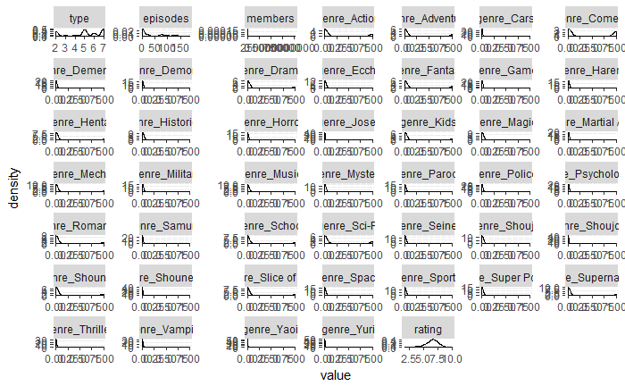

```r
ggplot(aniMat.melt,aes(x=value))+geom_density()+facet_wrap(~variable,scales="free")
```

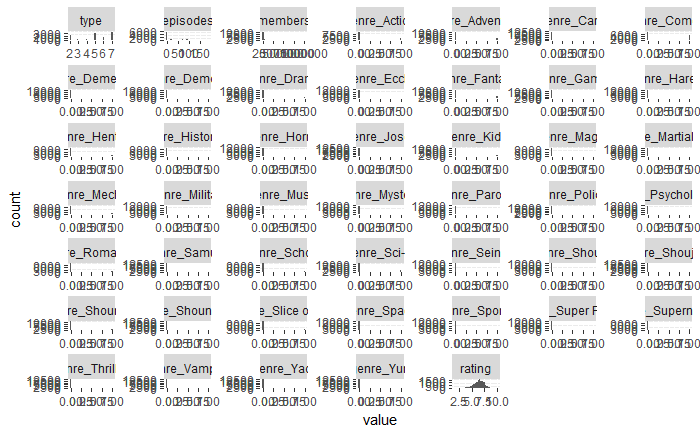

```r
ggplot(aniMat.melt,aes(x=value))+geom_histogram()+facet_wrap(~variable,scales="free")
```

confidence interval of rating

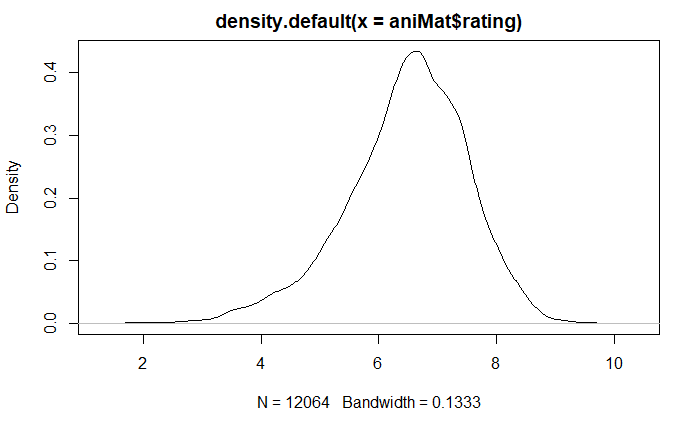

```r
#cannot use shapiro test to test normality because sample size is larger than 5000
plot(density(aniMat$rating))
```

```r
#CI for normal appointment
t.test(aniMat$rating)
```

```
    One Sample t-test

data:  aniMat$rating
t = 692.55, df = 12063, p-value < 2.2e-16
alternative hypothesis: true mean is not equal to 0
95 percent confidence interval:
 6.455578 6.492225
sample estimates:
mean of x
 6.473902
```

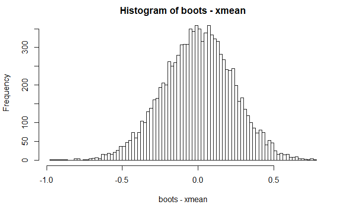

```r
#CI for normal appointment
x = aniMat$rating
xmean = mean(x)
boots = matrix(0,10000,1)
for(i in 1:10000){
  xsample = sample(x,size = 20,replace = TRUE)
  boots[i] = mean(xsample)
}
hist(boots-xmean,100)
```

```r
xmean+quantile(boots-xmean,c(0.05,0.95))
```

```
      5%      95%
6.088500 6.850525
```

see correlation

```r
cor(aniMat)
```

```
                             type      episodes      members genre_Action
type                 1.0000000000  0.4540115073  0.206586586  0.063824193
episodes             0.4540115073  1.0000000000  0.021934652  0.019678208
members              0.2065865861  0.0219346521  1.000000000  0.156604548
genre_Action         0.0638241934  0.0196782078  0.156604548  1.000000000
genre_Adventure      0.0088461655  0.0621768743  0.010990206  0.169986238
genre_Cars           0.0166602315  0.0209025941 -0.015624619  0.031942319
genre_Comedy         0.1874938224  0.1044787071  0.070514690 -0.084390311
genre_Dementia      -0.1811662198 -0.0974179481 -0.027911630 -0.063235359
genre_Demons         0.0153833475  0.0240828737  0.040977188  0.080397427
genre_Drama         -0.0029603337 -0.0471047519  0.087962198  0.002871211
genre_Ecchi          0.0968450183  0.0218839899  0.090695483  0.036305368
genre_Fantasy       -0.0264377035 -0.0181120432  0.059729380  0.078346690
genre_Game           0.0638232441  0.0459591060  0.042594308  0.056383481
genre_Harem          0.0961631209 -0.0085805678  0.132949043 -0.005971804
genre_Hentai        -0.0083730621  0.1077921667 -0.090903122 -0.148647236
genre_Historical    -0.0161373243 -0.0088316000 -0.019396770 -0.004834845
genre_Horror        -0.0020976733 -0.0007357638  0.052048719  0.040375623
genre_Josei          0.0432025275  0.0037165553  0.028691824 -0.008820066
genre_Kids          -0.0700948768 -0.0576282260 -0.116094045 -0.141111216
genre_Magic          0.0680283090  0.0730549443  0.044585191  0.045483797
genre_Martial Arts   0.0156929567  0.0172625903  0.023366371  0.191915370
genre_Mecha          0.0485516680  0.0757718757 -0.011929027  0.266088268
genre_Military      -0.0065269478 -0.0075045080  0.037352057  0.172380995
genre_Music         -0.1828496768 -0.1421475658 -0.055249648 -0.110012264
genre_Mystery        0.0491697307 -0.0265263702  0.137021924  0.042873278
genre_Parody         0.0467136797  0.0328819473  0.004011675 -0.018064052
genre_Police        -0.0116025740 -0.0132940518  0.015690096  0.066061917
genre_Psychological -0.0122320653 -0.0207570814  0.144290188 -0.001241885
genre_Romance        0.1161060202  0.0130034511  0.181196545 -0.056422324
genre_Samurai        0.0108865082 -0.0071387373  0.011826385  0.116292245
genre_School         0.1321472086  0.0177826094  0.167879905 -0.054383628
genre_Sci-Fi         0.0458772054  0.0422837496  0.029181657  0.286250725
genre_Seinen         0.0702316686 -0.0177957838  0.097156989  0.057549600
genre_Shoujo         0.0718165252  0.0564832928  0.017814654 -0.060398699
genre_Shoujo Ai      0.0437128913 -0.0034526391  0.020870219 -0.001151510
genre_Shounen        0.0611408824  0.0613643420  0.099223669  0.219540295
genre_Shounen Ai     0.0220465866 -0.0195711961  0.005820562 -0.019920642
genre_Slice of Life  0.0947296460  0.0026116573  0.049598550 -0.164590592
genre_Space         -0.0090540513  0.0126810967 -0.016016039  0.137662074
```

[output cut: 521 more lines]

```
genre_Seinen        -0.0120735420  0.0082689888  0.1030201042
genre_Shoujo        -0.0127921255 -0.0132891443  0.0891195848
genre_Shoujo Ai     -0.0037692642  0.0387574256  0.0329323773
genre_Shounen       -0.0226336013 -0.0235129959  0.2290944176
genre_Shounen Ai    -0.0040401755 -0.0041971505  0.0341418165
genre_Slice of Life -0.0137814424 -0.0194439205  0.0832154872
genre_Space         -0.0100960235 -0.0104882893  0.0366475232
genre_Sports         0.0023115864 -0.0125549684  0.0636739014
genre_Super Power   -0.0110776402 -0.0115080453  0.0830886441
genre_Supernatural  -0.0008205892 -0.0175657253  0.1542466012
genre_Thriller      -0.0047630843 -0.0049481468  0.0749722370
genre_Vampire        0.0111763427 -0.0053388449  0.0365712297
genre_Yaoi           1.0000000000 -0.0032825905 -0.0022019168
genre_Yuri          -0.0032825905  1.0000000000 -0.0219185966
rating              -0.0022019168 -0.0219185966  1.0000000000
```

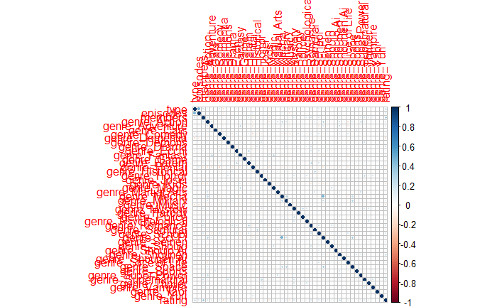

```r
library(corrplot)
corrplot(cor(aniMat))
```

there are high correlations between genre_Mecha and genre_Sci-Fi, also genre_space and genre_SciFi.

plot bivariate graphs including Y

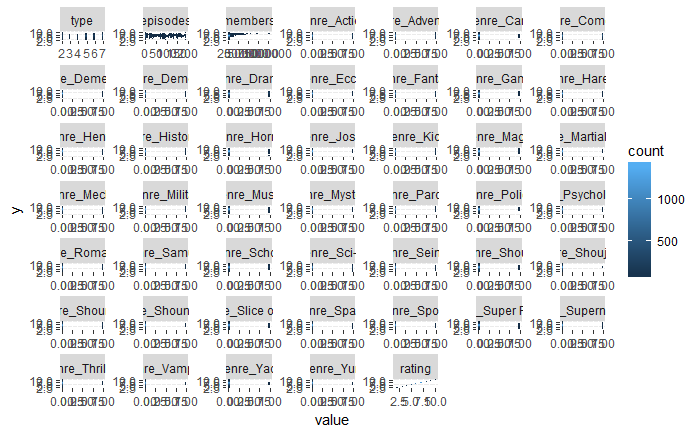

```r
aniMat.melt2 <- cbind(aniMat.melt,y=aniMat$rating)
ggplot(aniMat.melt2,aes(x=value,y=y))+stat_bin2d()+facet_wrap(~variable,scales="free")
```

```r
library(leaps)
regfit.full <- regsubsets(rating~.,aniMat,nvmax=46)
summary(regfit.full)
```

```
Subset selection object
Call: regsubsets.formula(rating ~ ., aniMat, nvmax = 46)
46 Variables  (and intercept)
                      Forced in Forced out
type                      FALSE      FALSE
episodes                  FALSE      FALSE
members                   FALSE      FALSE
genre_Action              FALSE      FALSE
genre_Adventure           FALSE      FALSE
genre_Cars                FALSE      FALSE
genre_Comedy              FALSE      FALSE
genre_Dementia            FALSE      FALSE
genre_Demons              FALSE      FALSE
genre_Drama               FALSE      FALSE
genre_Ecchi               FALSE      FALSE
```

[output cut: 460 more lines]

```r
regfit.summary <- summary(regfit.full)
names(regfit.summary)
```

```
[1] "which"  "rsq"    "rss"    "adjr2"  "cp"     "bic"    "outmat" "obj"
```

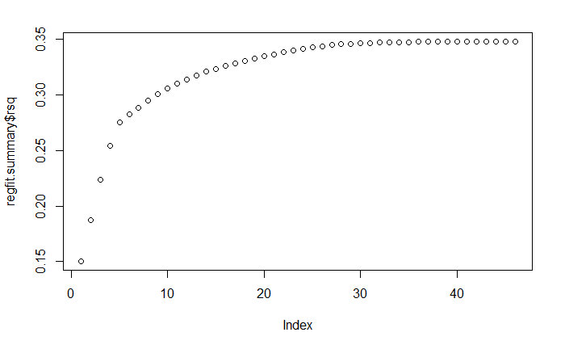

```r
plot(regfit.summary$rsq)
```

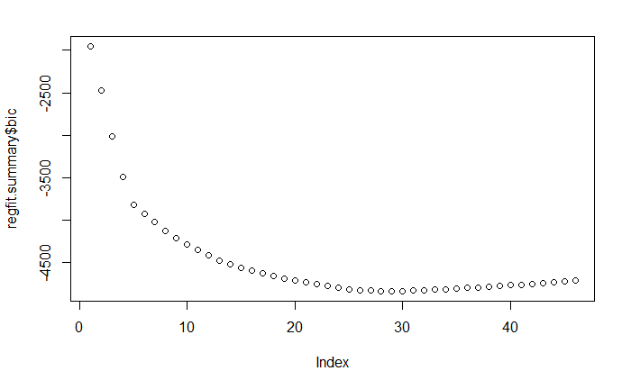

```r
plot(regfit.summary$bic)
```

```r
which.min(regfit.summary$bic)
```

```
[1] 28
```

The lowest BIC is achieved by the 28th model.

```r
coef(regfit.full,28)
```

```
          (Intercept)                  type              episodes
         5.647145e+00          4.744843e-02          1.026365e-03
              members          genre_Action       genre_Adventure
         4.789444e-06          1.114185e-01          1.852201e-01
         genre_Comedy        genre_Dementia           genre_Drama
         1.235342e-01         -8.978793e-01          4.398791e-01
        genre_Fantasy          genre_Hentai      genre_Historical
         2.216945e-01          1.519620e-01          2.779923e-01
         genre_Horror           genre_Josei            genre_Kids
        -2.330353e-01          6.380866e-01         -1.242205e-01
       genre_Military           genre_Music         genre_Mystery
         3.483140e-01         -1.226090e-01          4.414764e-01
         genre_Police   genre_Psychological         genre_Romance
         3.673685e-01          2.282417e-01          1.645713e-01
         genre_School        `genre_Sci-Fi`          genre_Seinen
         2.724276e-01          1.514120e-01          2.957845e-01
         genre_Shoujo         genre_Shounen `genre_Slice of Life`
         2.844546e-01          4.221651e-01          2.225909e-01
         genre_Sports    genre_Supernatural
         2.524472e-01          1.867823e-01
```

We will also check the models chosen by best subset selection using cross validation.

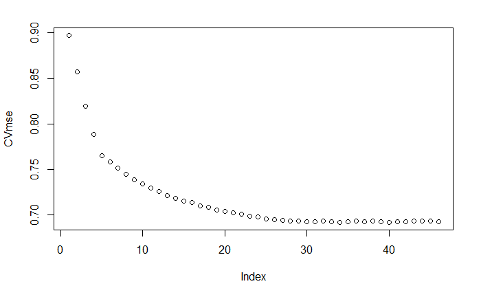

```r
library(boot)
CVmse <- rep(0,46)
for(i in 1:46){
tempCols <- which(regfit.summary$which[i,-1]==TRUE)
tempCols <- c(tempCols,47)
tempCols <- as.numeric(tempCols)
tempGLM <- glm(rating~.,data=aniMat[,tempCols])
tempCV <- cv.glm(tempGLM,data=aniMat[,tempCols],K = 10)
CVmse[i] <- tempCV$delta[1]
}
plot(CVmse)
```

```r
print(which.min(CVmse))
```

```
[1] 34
```

```r
print(min(CVmse))
```

```
[1] 0.6919255
```

```r
print(CVmse)
```

```
 [1] 0.8975492 0.8572266 0.8192139 0.7881636 0.7649230 0.7579734 0.7512906 0.7447025
 [9] 0.7387659 0.7338160 0.7293730 0.7256772 0.7212586 0.7180359 0.7151922 0.7135129
[17] 0.7100341 0.7083080 0.7055245 0.7039722 0.7024733 0.7010786 0.6987622 0.6975737
[25] 0.6956366 0.6950505 0.6941590 0.6931062 0.6929829 0.6924256 0.6928092 0.6931074
[33] 0.6924164 0.6919255 0.6921300 0.6928772 0.6923475 0.6932914 0.6922698 0.6920578
[41] 0.6927914 0.6927983 0.6931168 0.6928472 0.6930542 0.6926005
```

Forward Stepwise Selection

```r
regfit.fwd <- regsubsets(rating~.,aniMat,nvmax=46,method="forward")
summary(regfit.fwd)
```

[output not shown]

```r
regfit.fwd.summary <- summary(regfit.fwd)
which.min(regfit.fwd.summary$bic)
```

[output not shown]

Backward Stepwise Selection

```r
regfit.bwd <- regsubsets(rating~.,aniMat,nvmax=46,method="backward")
summary(regfit.bwd)
```

```
Subset selection object
Call: regsubsets.formula(rating ~ ., aniMat, nvmax = 46, method = "backward")
46 Variables  (and intercept)
                      Forced in Forced out
type                      FALSE      FALSE
episodes                  FALSE      FALSE
members                   FALSE      FALSE
genre_Action              FALSE      FALSE
genre_Adventure           FALSE      FALSE
genre_Cars                FALSE      FALSE
genre_Comedy              FALSE      FALSE
genre_Dementia            FALSE      FALSE
genre_Demons              FALSE      FALSE
genre_Drama               FALSE      FALSE
genre_Ecchi               FALSE      FALSE
```

[output cut: 460 more lines]

```r
regfit.bwd.summary <- summary(regfit.bwd)
which.min(regfit.bwd.summary$bic)
```

```
[1] 28
```

LASSO

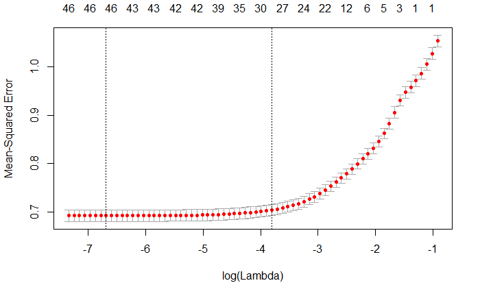

```r
lasso.cv <- cv.glmnet(x=as.matrix(aniMat[,-47]),y=as.matrix(aniMat[,47]),alpha=1,nfolds = 10)
plot(lasso.cv)
```

```r
print(min(lasso.cv$cvm))
```

```
[1] 0.6925283
```

The lost mse from LASSO is a little bit higher than the one I obtained with best subset selection.So the best model up to now is from best subset selection.